# Summary of my Work

- I have experiemeted with all models those we have learned in the class.
- The file takes around 15-20 minutes to process the file.
- By reading the background, context and after high level overview of the data, predicting that features likes having good monthly income, age, Number of trips taken (shows interest in travel in general) and customer interactive data like 'duration of pitch' are important and influence customer to purchase a new product.
- Not sure why Owning car and passport are important features. But I will try to learn from the models which i'm going to build about these features. I would keep them than dropping columns. It is my personal experience that many resorts are in driving distance too.
- I have used feature engineering techniques such as one hot encoding, handled 'Fe Male' in gender (wrongly typed) where they should not be, outlier detection and grouping into different sigments so that it is easier to make recommendations and thus reducing to few columns.
- For most of the missing values replaced with median values since I noticed from the data all these are right/left skewed.
- ProdTaken is the dependent variable. About 18% are only taken. There is a huge opportunity for upsell.
- Basic is the product which was taken by majority of the customers, not sure it is relatively effective one or promoted aggresively. Similar startegy could implement for the new product too.
- Time for looking into the data and see if there is any support for assumptions/predictions.

### Loading all required libraries to perform Assignment.

```python
# Library to suppress warnings or deprecation notes
import warnings
warnings.filterwarnings('ignore')

# Libraries to help with reading and manipulating data
import numpy as np
import pandas as pd

# Libraries to help with data visualization
import matplotlib.pyplot as plt
%matplotlib inline
import seaborn as sns

# Libraries to split data, impute missing values
from sklearn.model_selection import train_test_split
from sklearn.impute import SimpleImputer

# Libraries to import decision tree classifier and different ensemble classifiers
from sklearn.ensemble import BaggingClassifier
from sklearn.ensemble import RandomForestClassifier
from sklearn.ensemble import AdaBoostClassifier, GradientBoostingClassifier
from xgboost import XGBClassifier
from sklearn.ensemble import StackingClassifier
from sklearn.tree import DecisionTreeClassifier

# Libraries to tune model, get different metric scores
from sklearn import metrics
from sklearn.metrics import confusion_matrix, classification_report, accuracy_score, precision_score, recall_score, f1_score, roc_auc_score
from sklearn.model_selection import GridSearchCV
```

### Load and overview the dataset

```python
df = pd.read_excel('Tourism.xlsx', sheet_name='Tourism')
#df = pd.read_excel('File.xlsx', sheetname='Sheet1')
```

```python
df.head()
```

|  | CustomerID | ProdTaken | Age | TypeofContact | CityTier | DurationOfPitch | Occupation | Gender | NumberOfPersonVisiting | NumberOfFollowups | ProductPitched | PreferredPropertyStar | MaritalStatus | NumberOfTrips | Passport | PitchSatisfactionScore | OwnCar | NumberOfChildrenVisiting | Designation | MonthlyIncome |
| --- | --- | --- | --- | --- | --- | --- | --- | --- | --- | --- | --- | --- | --- | --- | --- | --- | --- | --- | --- | --- |
| 0 | 200000 | 1 | 41.0 | Self Enquiry | 3 | 6.0 | Salaried | Female | 3 | 3.0 | Deluxe | 3.0 | Single | 1.0 | 1 | 2 | 1 | 0.0 | Manager | 20993.0 |
| 1 | 200001 | 0 | 49.0 | Company Invited | 1 | 14.0 | Salaried | Male | 3 | 4.0 | Deluxe | 4.0 | Divorced | 2.0 | 0 | 3 | 1 | 2.0 | Manager | 20130.0 |
| 2 | 200002 | 1 | 37.0 | Self Enquiry | 1 | 8.0 | Free Lancer | Male | 3 | 4.0 | Basic | 3.0 | Single | 7.0 | 1 | 3 | 0 | 0.0 | Executive | 17090.0 |
| 3 | 200003 | 0 | 33.0 | Company Invited | 1 | 9.0 | Salaried | Female | 2 | 3.0 | Basic | 3.0 | Divorced | 2.0 | 1 | 5 | 1 | 1.0 | Executive | 17909.0 |
| 4 | 200004 | 0 | NaN | Self Enquiry | 1 | 8.0 | Small Business | Male | 2 | 3.0 | Basic | 4.0 | Divorced | 1.0 | 0 | 5 | 1 | 0.0 | Executive | 18468.0 |

### Printing columns names

```python
print("Column headings:")
print(df.columns)
```

```
Column headings:
Index(['CustomerID', 'ProdTaken', 'Age', 'TypeofContact', 'CityTier',
       'DurationOfPitch', 'Occupation', 'Gender', 'NumberOfPersonVisiting',
       'NumberOfFollowups', 'ProductPitched', 'PreferredPropertyStar',
       'MaritalStatus', 'NumberOfTrips', 'Passport', 'PitchSatisfactionScore',
       'OwnCar', 'NumberOfChildrenVisiting', 'Designation', 'MonthlyIncome'],
      dtype='object')
```

### Check the data types of the columns in the dataset.

```python
df.info()
```

```
<class 'pandas.core.frame.DataFrame'>
RangeIndex: 4888 entries, 0 to 4887
Data columns (total 20 columns):
 #   Column                    Non-Null Count  Dtype
---  ------                    --------------  -----
 0   CustomerID                4888 non-null   int64
 1   ProdTaken                 4888 non-null   int64
 2   Age                       4662 non-null   float64
 3   TypeofContact             4863 non-null   object
 4   CityTier                  4888 non-null   int64
 5   DurationOfPitch           4637 non-null   float64
 6   Occupation                4888 non-null   object
 7   Gender                    4888 non-null   object
 8   NumberOfPersonVisiting    4888 non-null   int64
 9   NumberOfFollowups         4843 non-null   float64
 10  ProductPitched            4888 non-null   object
 11  PreferredPropertyStar     4862 non-null   float64
 12  MaritalStatus             4888 non-null   object
 13  NumberOfTrips             4748 non-null   float64
 14  Passport                  4888 non-null   int64
 15  PitchSatisfactionScore    4888 non-null   int64
 16  OwnCar                    4888 non-null   int64
 17  NumberOfChildrenVisiting  4822 non-null   float64
 18  Designation               4888 non-null   object
 19  MonthlyIncome             4655 non-null   float64
dtypes: float64(7), int64(7), object(6)
memory usage: 763.9+ KB
```

### Convert columns with an 'object' datatype into categorical variables

```python
for feature in df.columns: # Loop through all columns in the dataframe
    if df[feature].dtype == 'object': # Only apply for columns with categorical strings
        df[feature] = pd.Categorical(df[feature])# Replace strings with an integer
df.head(10)
```

|  | CustomerID | ProdTaken | Age | TypeofContact | CityTier | DurationOfPitch | Occupation | Gender | NumberOfPersonVisiting | NumberOfFollowups | ProductPitched | PreferredPropertyStar | MaritalStatus | NumberOfTrips | Passport | PitchSatisfactionScore | OwnCar | NumberOfChildrenVisiting | Designation | MonthlyIncome |
| --- | --- | --- | --- | --- | --- | --- | --- | --- | --- | --- | --- | --- | --- | --- | --- | --- | --- | --- | --- | --- |
| 0 | 200000 | 1 | 41.0 | Self Enquiry | 3 | 6.0 | Salaried | Female | 3 | 3.0 | Deluxe | 3.0 | Single | 1.0 | 1 | 2 | 1 | 0.0 | Manager | 20993.0 |
| 1 | 200001 | 0 | 49.0 | Company Invited | 1 | 14.0 | Salaried | Male | 3 | 4.0 | Deluxe | 4.0 | Divorced | 2.0 | 0 | 3 | 1 | 2.0 | Manager | 20130.0 |
| 2 | 200002 | 1 | 37.0 | Self Enquiry | 1 | 8.0 | Free Lancer | Male | 3 | 4.0 | Basic | 3.0 | Single | 7.0 | 1 | 3 | 0 | 0.0 | Executive | 17090.0 |
| 3 | 200003 | 0 | 33.0 | Company Invited | 1 | 9.0 | Salaried | Female | 2 | 3.0 | Basic | 3.0 | Divorced | 2.0 | 1 | 5 | 1 | 1.0 | Executive | 17909.0 |
| 4 | 200004 | 0 | NaN | Self Enquiry | 1 | 8.0 | Small Business | Male | 2 | 3.0 | Basic | 4.0 | Divorced | 1.0 | 0 | 5 | 1 | 0.0 | Executive | 18468.0 |
| 5 | 200005 | 0 | 32.0 | Company Invited | 1 | 8.0 | Salaried | Male | 3 | 3.0 | Basic | 3.0 | Single | 1.0 | 0 | 5 | 1 | 1.0 | Executive | 18068.0 |
| 6 | 200006 | 0 | 59.0 | Self Enquiry | 1 | 9.0 | Small Business | Female | 2 | 2.0 | Basic | 5.0 | Divorced | 5.0 | 1 | 2 | 1 | 1.0 | Executive | 17670.0 |
| 7 | 200007 | 0 | 30.0 | Self Enquiry | 1 | 30.0 | Salaried | Male | 3 | 3.0 | Basic | 3.0 | Married | 2.0 | 0 | 2 | 0 | 1.0 | Executive | 17693.0 |
| 8 | 200008 | 0 | 38.0 | Company Invited | 1 | 29.0 | Salaried | Male | 2 | 4.0 | Standard | 3.0 | Unmarried | 1.0 | 0 | 3 | 0 | 0.0 | Senior Manager | 24526.0 |
| 9 | 200009 | 0 | 36.0 | Self Enquiry | 1 | 33.0 | Small Business | Male | 3 | 3.0 | Deluxe | 3.0 | Divorced | 7.0 | 0 | 3 | 1 | 0.0 | Manager | 20237.0 |

```python
df.info()
```

```
<class 'pandas.core.frame.DataFrame'>
RangeIndex: 4888 entries, 0 to 4887
Data columns (total 20 columns):
 #   Column                    Non-Null Count  Dtype
---  ------                    --------------  -----
 0   CustomerID                4888 non-null   int64
 1   ProdTaken                 4888 non-null   int64
 2   Age                       4662 non-null   float64
 3   TypeofContact             4863 non-null   category
 4   CityTier                  4888 non-null   int64
 5   DurationOfPitch           4637 non-null   float64
 6   Occupation                4888 non-null   category
 7   Gender                    4888 non-null   category
 8   NumberOfPersonVisiting    4888 non-null   int64
 9   NumberOfFollowups         4843 non-null   float64
 10  ProductPitched            4888 non-null   category
 11  PreferredPropertyStar     4862 non-null   float64
 12  MaritalStatus             4888 non-null   category
 13  NumberOfTrips             4748 non-null   float64
 14  Passport                  4888 non-null   int64
 15  PitchSatisfactionScore    4888 non-null   int64
 16  OwnCar                    4888 non-null   int64
 17  NumberOfChildrenVisiting  4822 non-null   float64
 18  Designation               4888 non-null   category
 19  MonthlyIncome             4655 non-null   float64
dtypes: category(6), float64(7), int64(7)
memory usage: 564.5 KB
```

### Checking missing values

```python
df.isnull().sum().sort_values(ascending = False)
```

```
DurationOfPitch             251
MonthlyIncome               233
Age                         226
NumberOfTrips               140
NumberOfChildrenVisiting     66
NumberOfFollowups            45
PreferredPropertyStar        26
TypeofContact                25
Designation                   0
OwnCar                        0
PitchSatisfactionScore        0
Passport                      0
CustomerID                    0
MaritalStatus                 0
ProdTaken                     0
NumberOfPersonVisiting        0
Gender                        0
Occupation                    0
CityTier                      0
ProductPitched                0
dtype: int64
```

- Few missing values are found in the data set. I will handle them at later stage.

```python
 ['TypeofContact','Occupation','Gender','ProductPitched','MaritalStatus','Designation']
#only type of contact is missing from cat columns.
```

```
['TypeofContact',
 'Occupation',
 'Gender',
 'ProductPitched',
 'MaritalStatus',
 'Designation']
```

- Only type of contact is missing from cat columns.

```python
df.describe().T
```

|  | count | mean | std | min | 25% | 50% | 75% | max |
| --- | --- | --- | --- | --- | --- | --- | --- | --- |
| CustomerID | 4888.0 | 202443.500000 | 1411.188388 | 200000.0 | 201221.75 | 202443.5 | 203665.25 | 204887.0 |
| ProdTaken | 4888.0 | 0.188216 | 0.390925 | 0.0 | 0.00 | 0.0 | 0.00 | 1.0 |
| Age | 4662.0 | 37.622265 | 9.316387 | 18.0 | 31.00 | 36.0 | 44.00 | 61.0 |
| CityTier | 4888.0 | 1.654255 | 0.916583 | 1.0 | 1.00 | 1.0 | 3.00 | 3.0 |
| DurationOfPitch | 4637.0 | 15.490835 | 8.519643 | 5.0 | 9.00 | 13.0 | 20.00 | 127.0 |
| NumberOfPersonVisiting | 4888.0 | 2.905074 | 0.724891 | 1.0 | 2.00 | 3.0 | 3.00 | 5.0 |
| NumberOfFollowups | 4843.0 | 3.708445 | 1.002509 | 1.0 | 3.00 | 4.0 | 4.00 | 6.0 |
| PreferredPropertyStar | 4862.0 | 3.581037 | 0.798009 | 3.0 | 3.00 | 3.0 | 4.00 | 5.0 |
| NumberOfTrips | 4748.0 | 3.236521 | 1.849019 | 1.0 | 2.00 | 3.0 | 4.00 | 22.0 |
| Passport | 4888.0 | 0.290917 | 0.454232 | 0.0 | 0.00 | 0.0 | 1.00 | 1.0 |
| PitchSatisfactionScore | 4888.0 | 3.078151 | 1.365792 | 1.0 | 2.00 | 3.0 | 4.00 | 5.0 |
| OwnCar | 4888.0 | 0.620295 | 0.485363 | 0.0 | 0.00 | 1.0 | 1.00 | 1.0 |
| NumberOfChildrenVisiting | 4822.0 | 1.187267 | 0.857861 | 0.0 | 1.00 | 1.0 | 2.00 | 3.0 |
| MonthlyIncome | 4655.0 | 23619.853491 | 5380.698361 | 1000.0 | 20346.00 | 22347.0 | 25571.00 | 98678.0 |

### Observations -

- Minimum age is around 36 for about 50% of the data, max is around 61, could be an outlier.
- DurationOfPitch is around 20 sec for about 75%. Noted 127 is max, could be an outlier
- Number of trips is 3 for 50% customerss, one is around 22 times.
- Median Monthly Income is around 22,000 , about 75% it is within 26,000. Max is around 98600.
- Passport, ownCar and prod taken are yes/no columns. ProdTaken is a dependent variable.

```python
# Getting unique values on different columns
cat_cols = ['TypeofContact','Occupation','Gender','ProductPitched','MaritalStatus','Designation']

#printing the count
for col in cat_cols:
    print(df[col].value_counts())
    print("*" * 50)
```

```
Self Enquiry       3444
Company Invited    1419
Name: TypeofContact, dtype: int64
Salaried          2368
Small Business    2084
Large Business     434
Free Lancer          2
Name: Occupation, dtype: int64
Male       2916
Female     1817
Fe Male     155
Name: Gender, dtype: int64
Basic           1842
Deluxe          1732
Standard         742
Super Deluxe     342
King             230
Name: ProductPitched, dtype: int64
Married      2340
Divorced      950
Single        916
Unmarried     682
Name: MaritalStatus, dtype: int64
Executive         1842
Manager           1732
Senior Manager     742
AVP                342
VP                 230
Name: Designation, dtype: int64
```

- Noticed there are few rows with 'Fe Male' in Gender column. Need to treat this. No missing values in this Gender column

```python
# Getting unique values on different columns which has 1 or 0 values (yes/no - kind of boolean)
cols = ['Passport','OwnCar','ProdTaken']

#printing the count
for col in cols:
    print(df[col].value_counts())
    print("*" * 50)
```

```
0    3466
1    1422
Name: Passport, dtype: int64
1    3032
0    1856
Name: OwnCar, dtype: int64
0    3968
1     920
Name: ProdTaken, dtype: int64
```

```python
# Creating a copy
df1 = df.copy()
```

```python
#Dropping customer ID column from dataframe, which is unique
df1.drop(columns=['CustomerID'], inplace=True)
```

- CustomerId is a unique column, dropped customer ID column from dataframe

```python
df1.info()
```

```
<class 'pandas.core.frame.DataFrame'>
RangeIndex: 4888 entries, 0 to 4887
Data columns (total 19 columns):
 #   Column                    Non-Null Count  Dtype
---  ------                    --------------  -----
 0   ProdTaken                 4888 non-null   int64
 1   Age                       4662 non-null   float64
 2   TypeofContact             4863 non-null   category
 3   CityTier                  4888 non-null   int64
 4   DurationOfPitch           4637 non-null   float64
 5   Occupation                4888 non-null   category
 6   Gender                    4888 non-null   category
 7   NumberOfPersonVisiting    4888 non-null   int64
 8   NumberOfFollowups         4843 non-null   float64
 9   ProductPitched            4888 non-null   category
 10  PreferredPropertyStar     4862 non-null   float64
 11  MaritalStatus             4888 non-null   category
 12  NumberOfTrips             4748 non-null   float64
 13  Passport                  4888 non-null   int64
 14  PitchSatisfactionScore    4888 non-null   int64
 15  OwnCar                    4888 non-null   int64
 16  NumberOfChildrenVisiting  4822 non-null   float64
 17  Designation               4888 non-null   category
 18  MonthlyIncome             4655 non-null   float64
dtypes: category(6), float64(7), int64(6)
memory usage: 526.3 KB
```

```python
#Removing the space from the Gender rows
df1.Gender = df1.Gender.str.strip().str.replace(' ', '')
```

```python
# getting the count
df1.Gender.value_counts()
```

```
Male      2916
Female    1817
FeMale     155
Name: Gender, dtype: int64
```

- Since FeMale has 'M' upper case, hence it is showing as a different type. Renaming FeMale to Female.

```python
# To rename FeMale to Female.
df1.Gender = [i.title() for i in df1.Gender]
```

```python
# Taking gender count
df1.Gender.value_counts()
```

```
Male      2916
Female    1972
Name: Gender, dtype: int64
```

- Gender column is fixed. The count is matching with total rows.

### Looking into Outliers

```python
#Monthly Income
df[df['MonthlyIncome'] >= 70000]
```

|  | CustomerID | ProdTaken | Age | TypeofContact | CityTier | DurationOfPitch | Occupation | Gender | NumberOfPersonVisiting | NumberOfFollowups | ProductPitched | PreferredPropertyStar | MaritalStatus | NumberOfTrips | Passport | PitchSatisfactionScore | OwnCar | NumberOfChildrenVisiting | Designation | MonthlyIncome |
| --- | --- | --- | --- | --- | --- | --- | --- | --- | --- | --- | --- | --- | --- | --- | --- | --- | --- | --- | --- | --- |
| 38 | 200038 | 0 | 36.0 | Self Enquiry | 1 | 11.0 | Salaried | Female | 2 | 4.0 | Basic | NaN | Divorced | 1.0 | 1 | 2 | 1 | 0.0 | Executive | 95000.0 |
| 2482 | 202482 | 0 | 37.0 | Self Enquiry | 1 | 12.0 | Salaried | Female | 3 | 5.0 | Basic | 5.0 | Divorced | 2.0 | 1 | 2 | 1 | 1.0 | Executive | 98678.0 |

- Two customers are making about 90k per month, both are holding executive designation. Their age is around 37. Some companies are paying very attractive salaries. This is okay to leave these rows without altering them.

```python
# Duration of Pitch
df[df['DurationOfPitch'] >= 40]
```

|  | CustomerID | ProdTaken | Age | TypeofContact | CityTier | DurationOfPitch | Occupation | Gender | NumberOfPersonVisiting | NumberOfFollowups | ProductPitched | PreferredPropertyStar | MaritalStatus | NumberOfTrips | Passport | PitchSatisfactionScore | OwnCar | NumberOfChildrenVisiting | Designation | MonthlyIncome |
| --- | --- | --- | --- | --- | --- | --- | --- | --- | --- | --- | --- | --- | --- | --- | --- | --- | --- | --- | --- | --- |
| 1434 | 201434 | 0 | NaN | Company Invited | 3 | 126.0 | Salaried | Male | 2 | 3.0 | Basic | 3.0 | Married | 3.0 | 0 | 1 | 1 | 1.0 | Executive | 18482.0 |
| 3878 | 203878 | 0 | 53.0 | Company Invited | 3 | 127.0 | Salaried | Male | 3 | 4.0 | Basic | 3.0 | Married | 4.0 | 0 | 1 | 1 | 2.0 | Executive | 22160.0 |

- There are two customers, The comapny spent about 120 seconds , in some cases it may be possible, hence not making any changes to it. It could be language issue or they have more questions.

```python
#Age
df[df['Age'] >= 60]['Age'].count()
```

```
38
```

- About 38 of them are above 60 years , all are making decent monthly income, not touching the data.

## EDA

### Univariate analysis

```python
# function to plot a boxplot and a histogram along the same scale.


def histogram_boxplot(data, feature, figsize=(12, 7), kde=False, bins=None):
    """
    Boxplot and histogram combined

    data: dataframe
    feature: dataframe column
    figsize: size of figure (default (12,7))
    kde: whether to show the density curve (default False)
    bins: number of bins for histogram (default None)
    """
    f2, (ax_box2, ax_hist2) = plt.subplots(
        nrows=2,  # Number of rows of the subplot grid= 2
        sharex=True,  # x-axis will be shared among all subplots
        gridspec_kw={"height_ratios": (0.25, 0.75)},
        figsize=figsize,
    )  # creating the 2 subplots
    sns.boxplot(
        data=data, x=feature, ax=ax_box2, showmeans=True, color="violet"
    )  # boxplot will be created and a star will indicate the mean value of the column
    sns.histplot(
        data=data, x=feature, kde=kde, ax=ax_hist2, bins=bins, palette="winter"
    ) if bins else sns.histplot(
        data=data, x=feature, kde=kde, ax=ax_hist2
    )  # For histogram
    ax_hist2.axvline(
        data[feature].mean(), color="green", linestyle="--"
    )  # Add mean to the histogram
    ax_hist2.axvline(
        data[feature].median(), color="black", linestyle="-"
    )  # Add median to the histogram
```

### Observations on Age

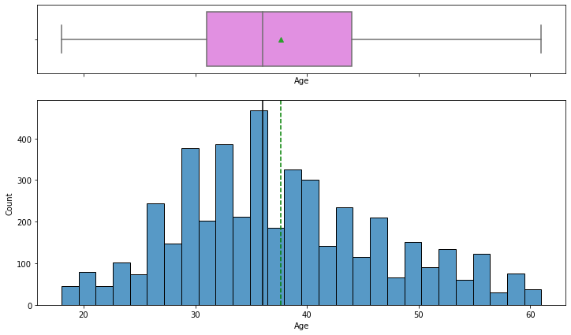

```python
histogram_boxplot(df1, "Age")
```

### Observations on MonthlyIncome

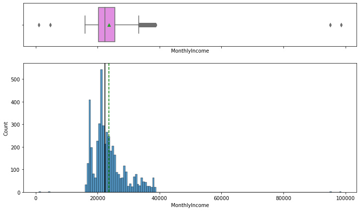

```python
histogram_boxplot(df1, "MonthlyIncome")
```

- The distribution of monthly income is right-skewed. Though there are few outliers.
- Few of them are making very good monthly income, a good candidates to sell the product.
- I woulld not treat these outliers as they represent the real market trend

### Observations on DurationOfPitch

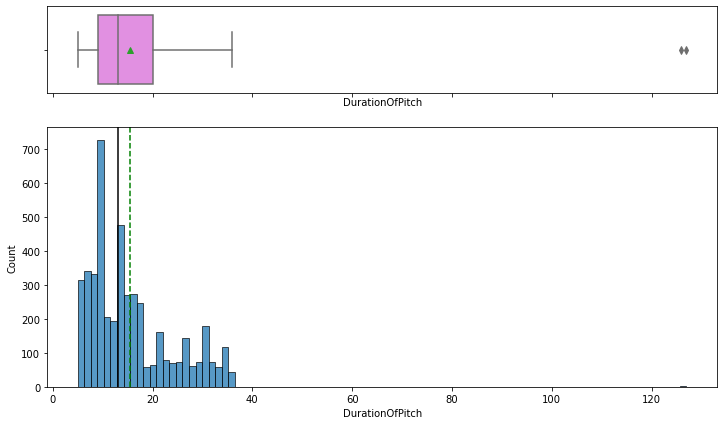

```python
histogram_boxplot(df1, "DurationOfPitch")
```

- The distribution of Duration of pitch is right-skewed. Though there are few outliers.
- Could be typo or took more time because they are opted to buy the package?

### Observations on NumberOfTrips

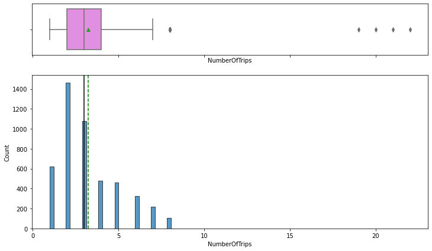

```python
histogram_boxplot(df1, "NumberOfTrips")
```

- The distribution of NumberOfTrips is right-skewed. Though there are few outliers.
- Noticed couple of them making a very good monthly income, could be the same customer made more number of trips?

### Observations on NumberOfChildrenVisiting

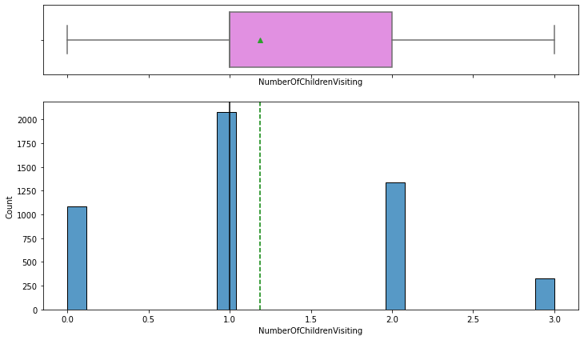

```python
histogram_boxplot(df1, "NumberOfChildrenVisiting")
```

- The distribution of NumberOfChildrenVisiting is right-skewed. Though there are no outliers.
- It should be considered as categorical column.

### Observations on NumberOfFollowups

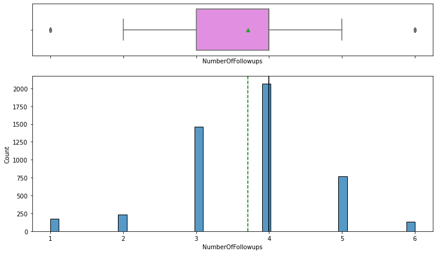

```python
histogram_boxplot(df1, "NumberOfFollowups")
```

### Observations on PreferredPropertyStar

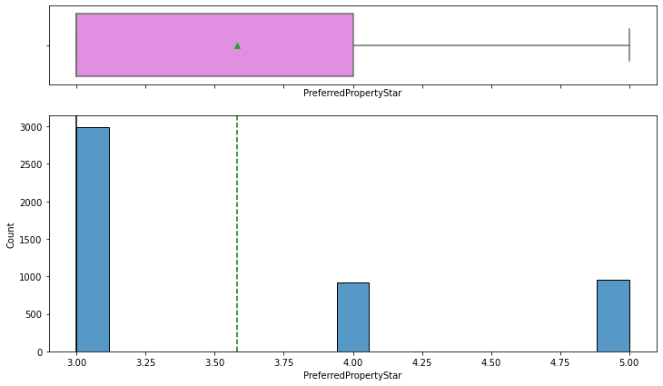

```python
histogram_boxplot(df1, "PreferredPropertyStar")
```

- The distribution of PreferredPropertyStar is right-skewed.
- It should be considered as categorical column too.

```python
# function to create labeled barplots


def labeled_barplot(data, feature, perc=False, n=None):
    """
    Barplot with percentage at the top

    data: dataframe
    feature: dataframe column
    perc: whether to display percentages instead of count (default is False)
    n: displays the top n category levels (default is None, i.e., display all levels)
    """

    total = len(data[feature])  # length of the column
    count = data[feature].nunique()
    if n is None:
        plt.figure(figsize=(count + 1, 5))
    else:
        plt.figure(figsize=(n + 1, 5))

    plt.xticks(rotation=90, fontsize=15)
    ax = sns.countplot(
        data=data,
        x=feature,
        palette="Paired",
        order=data[feature].value_counts().index[:n].sort_values(),
    )

    for p in ax.patches:
        if perc == True:
            label = "{:.1f}%".format(
                100 * p.get_height() / total
            )  # percentage of each class of the category
        else:
            label = p.get_height()  # count of each level of the category

        x = p.get_x() + p.get_width() / 2  # width of the plot
        y = p.get_height()  # height of the plot

        ax.annotate(
            label,
            (x, y),
            ha="center",
            va="center",
            size=12,
            xytext=(0, 5),
            textcoords="offset points",
        )  # annotate the percentage

    plt.show()  # show the plot
```

### Observations on Class

```python
df1.ProdTaken.value_counts()
#yes : 19% , No :81%
```

```
0    3968
1     920
Name: ProdTaken, dtype: int64
```

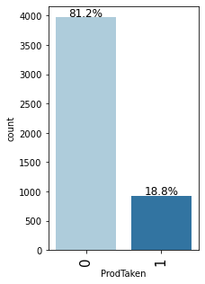

```python
labeled_barplot(df1,"ProdTaken",perc=True)
```

- The data is heavely imbalanced only 18.8% customers took the product compared to 81% not taken.Huge scope for selling the new product.

### Observations on Age

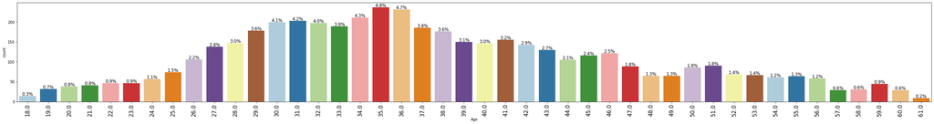

```python
labeled_barplot(df1,"Age",perc=True)
```

### Observations on NumberOfTrips

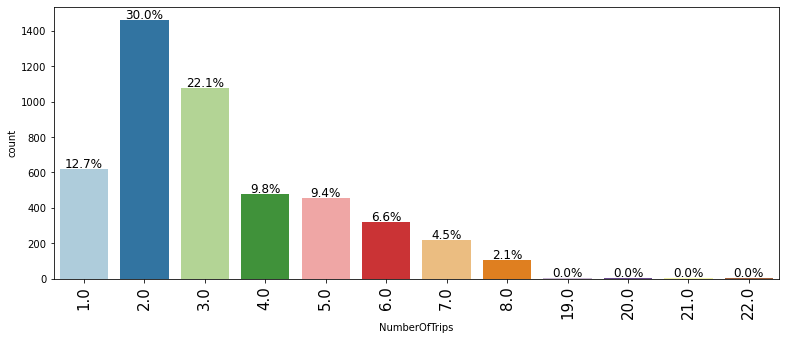

```python
labeled_barplot(df1,"NumberOfTrips",perc=True)
```

## Bivariate Analysis

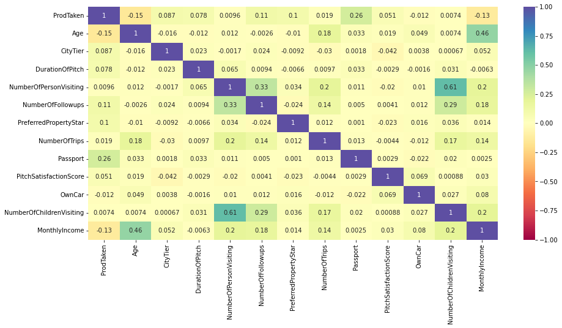

```python
plt.figure(figsize=(15,7))
sns.heatmap(df1.corr(),annot=True,vmin=-1,vmax=1,cmap="Spectral")
plt.show()
```

### Observations

- Dependent variable ProdTaken has no significant correlation with any independent variable.
- However both Age and MonthlyIncome have -ve correlation with ProdTaken.

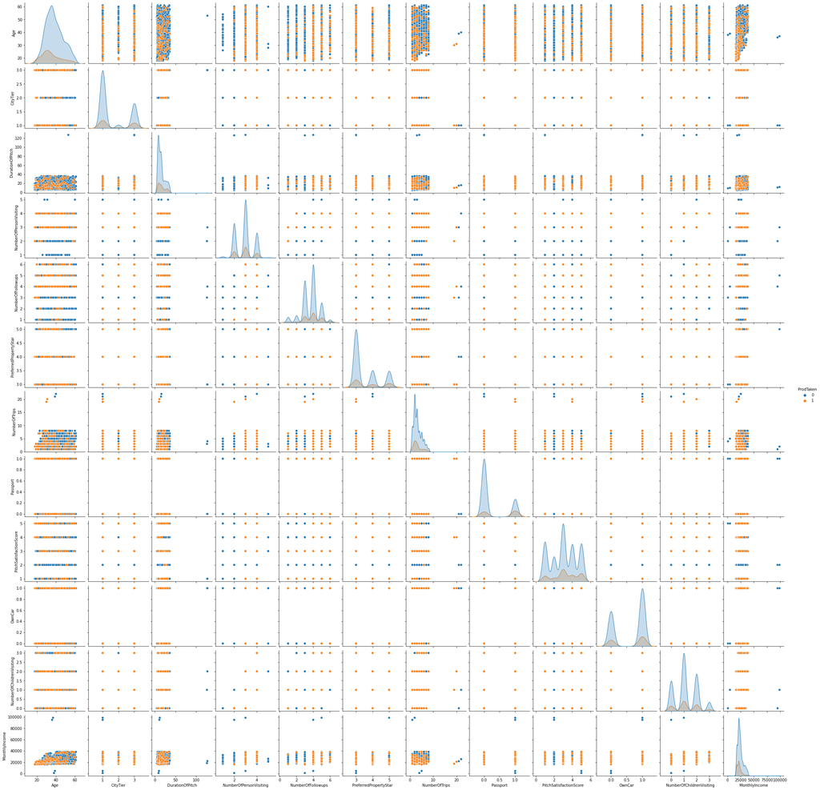

```python
sns.pairplot(data=df1,hue="ProdTaken")
plt.show()
```

- Not much information is getting from the pairploton other than what was seen box, pair plots. Need t investigate further with different models

```python
### Function to plot boxplot
def boxplot(x):
    plt.figure(figsize=(10,7))
    sns.boxplot(data=df1, x="ProdTaken",y=df1[x],palette="PuBu")
    plt.show()
```

### Specifically discussed with Customer interaction data

- Try to understand how prodtaken was influanced by Customer interaction data.

### ProdTaken vs NumberOfFollowups

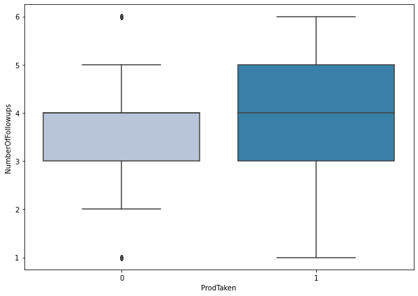

```python
boxplot('NumberOfFollowups')
```

- It clearly shows that as number of follow up increased, product was taken.

### ProdTaken vs PitchSatisfactionScore

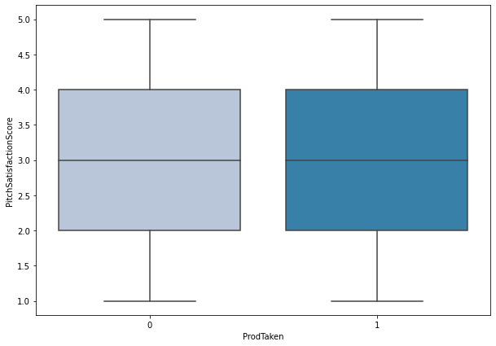

```python
boxplot('PitchSatisfactionScore')
```

- PitchSatisfactionScore do not have significant impact.

### ProdTaken vs ProductPitched

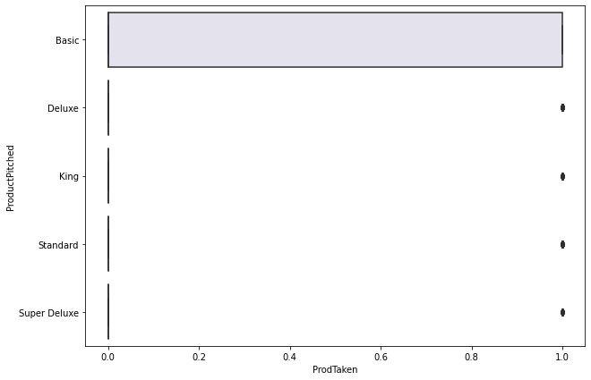

```python
boxplot('ProductPitched')
```

- ProductPitched - It was the most pitched product by sales team.
- Basic was taken by most of the customers. It is better to follow the same marketing strategy to sell the new product
- or may be better to bundle the new product with Basic by offering some incentive or discount.

### ProdTaken vs DurationOfPitch

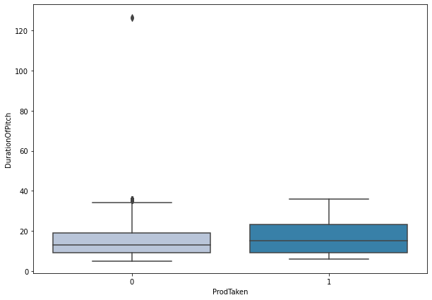

```python
boxplot('DurationOfPitch')
```

- The above graph shows product was taken when duration of pitch is high. Spending time customers and helping them to understand the product has good weightage in terms of selling products.

### ProdTaken vs Passport

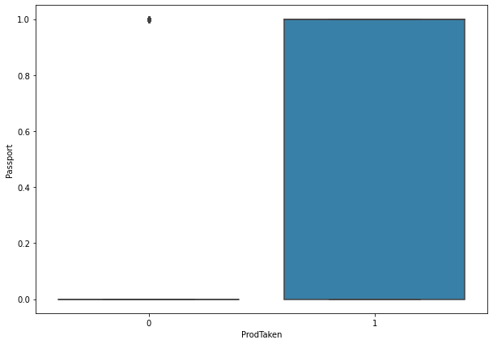

```python
boxplot('Passport')
```

- The above graph shows product was taken by customers who had passport.
- Still there is room to target these customers for the new product selling.

### ProdTaken vs CityTier

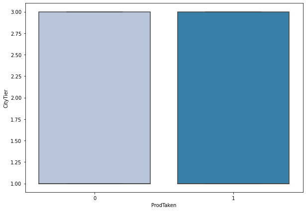

```python
boxplot('CityTier')
```

- Same thing with the citytier.
- Tier one living customers bought all types of product.
- There is a huge potential to sell the new product to tier one living customers.

```python
#Converting Gender column to category column
df1.Gender = df1.Gender.astype('category')
```

```python
df1.info()
```

```
<class 'pandas.core.frame.DataFrame'>
RangeIndex: 4888 entries, 0 to 4887
Data columns (total 19 columns):
 #   Column                    Non-Null Count  Dtype
---  ------                    --------------  -----
 0   ProdTaken                 4888 non-null   int64
 1   Age                       4662 non-null   float64
 2   TypeofContact             4863 non-null   category
 3   CityTier                  4888 non-null   int64
 4   DurationOfPitch           4637 non-null   float64
 5   Occupation                4888 non-null   category
 6   Gender                    4888 non-null   category
 7   NumberOfPersonVisiting    4888 non-null   int64
 8   NumberOfFollowups         4843 non-null   float64
 9   ProductPitched            4888 non-null   category
 10  PreferredPropertyStar     4862 non-null   float64
 11  MaritalStatus             4888 non-null   category
 12  NumberOfTrips             4748 non-null   float64
 13  Passport                  4888 non-null   int64
 14  PitchSatisfactionScore    4888 non-null   int64
 15  OwnCar                    4888 non-null   int64
 16  NumberOfChildrenVisiting  4822 non-null   float64
 17  Designation               4888 non-null   category
 18  MonthlyIncome             4655 non-null   float64
dtypes: category(6), float64(7), int64(6)
memory usage: 526.3 KB
```

## Missing value treatment

```python
df1.isnull().sum().sort_values(ascending = False)
```

```
DurationOfPitch             251
MonthlyIncome               233
Age                         226
NumberOfTrips               140
NumberOfChildrenVisiting     66
NumberOfFollowups            45
PreferredPropertyStar        26
TypeofContact                25
Designation                   0
OwnCar                        0
PitchSatisfactionScore        0
Passport                      0
ProdTaken                     0
MaritalStatus                 0
NumberOfPersonVisiting        0
Gender                        0
Occupation                    0
CityTier                      0
ProductPitched                0
dtype: int64
```

- The data description and plots shows all these columns are either left or right skewed. Hence using Median to replace missing values.
- TypeofContact column has 'Self 'Enquiry' more (about 75%) , hence using mode value replacing missing values.

```python
df1["DurationOfPitch"].fillna(df1.DurationOfPitch.median(), inplace = True)
df1["MonthlyIncome"].fillna(df1.MonthlyIncome.median(), inplace = True)
df1["Age"].fillna(df1.Age.median(), inplace = True)
df1["NumberOfTrips"].fillna(df1.NumberOfTrips.median(), inplace = True)
df1["NumberOfChildrenVisiting"].fillna(df1.NumberOfChildrenVisiting.median(), inplace = True)
df1["NumberOfFollowups"].fillna(df1.NumberOfFollowups.median(), inplace = True)
df1["PreferredPropertyStar"].fillna(df1.PreferredPropertyStar.median(), inplace = True)
#df1["TypeofContact"].fillna(df1.TypeofContact['Self Enquiry'], inplace = True)
df1.TypeofContact = df.TypeofContact.fillna('Self Enquiry')
```

- To reduce columns in different model , I would like to categorize the Occupation into two columns.
- Occupation into Self-Employed and Employed

```python
# Occupation column making into two columns.
pattern = '|'.join(['Small Business', 'Large Business', 'Free Lancer'])
df1['Occupation'] = df1['Occupation'].str.replace(pattern, 'Self-Employed')
```

```python
# Taking count on groups
df1.groupby(['Occupation'])['Occupation'].count()
```

```
Occupation
Salaried         2368
Self-Employed    2520
Name: Occupation, dtype: int64
```

- As I anticipated now both these have almost equal representation.
- I like to follow similar approach with MaritalStatus, Designation columns too.
- This helps to reduce the columns when I use them as one hot coding.

```python
# MaritalStatus column making into two columns only.
pattern = '|'.join(['Divorced', 'Single', 'Unmarried'])
df1['MaritalStatus'] = df1['MaritalStatus'].str.replace(pattern, 'NotMarried')
```

```python
# Taking count on groups
df1.groupby(['MaritalStatus'])['MaritalStatus'].count()
```

```
MaritalStatus
Married       2340
NotMarried    2548
Name: MaritalStatus, dtype: int64
```

```python
# Executive column making into two columns only.
pattern = '|'.join(['Executive', 'AVP', 'VP'])
df1['Designation'] = df1['Designation'].str.replace(pattern, 'Top Level Staff')
```

```python
# Taking count on groups
df1.groupby(['Designation'])['Designation'].count()
```

```
Designation
Manager            1732
Senior Manager      742
Top Level Staff    2414
Name: Designation, dtype: int64
```

```python
# Executive column making into two columns only.
pattern1 = '|'.join(['Manager', 'Senior Manager'])
df1['Designation'] = df1['Designation'].str.replace(pattern1, 'Mid Level Staff')
```

```python
# Taking count on groups
df1.groupby(['Designation'])['Designation'].count()
```

[output not shown]

```python
# Checking to make sure no missing values after treatment.
df1.isnull().sum()
```

```
ProdTaken                   0
Age                         0
TypeofContact               0
CityTier                    0
DurationOfPitch             0
Occupation                  0
Gender                      0
NumberOfPersonVisiting      0
NumberOfFollowups           0
ProductPitched              0
PreferredPropertyStar       0
MaritalStatus               0
NumberOfTrips               0
Passport                    0
PitchSatisfactionScore      0
OwnCar                      0
NumberOfChildrenVisiting    0
Designation                 0
MonthlyIncome               0
dtype: int64
```

### Setting ontHot columns.

```python
replaceStruct = {
                "TypeofContact":     {"Self Enquiry": 1, "Company Invited": 2},
                "Occupation": {"Salaried": 1, "Self-Employed":2},
                 "ProductPitched": {"Basic": 1, "Deluxe":2 , "Standard": 3, "Super Deluxe": 4,"King": 5},
                 "MaritalStatus":     {"Married": 1, "NotMarried": 2},
                 "Designation": {"Top Level Staff": 1, "Mid Level Staff":2},
                "Gender":     {"Male": 1, "Female": 2}
                    }
oneHotCols=["Passport","OwnCar", "TypeofContact","Occupation", "ProductPitched", "MaritalStatus", "Designation", "Gender" ]
```

## Summary of EDA

### Data Description:

- Dependent variable is 'ProdTaken' which is representing if the product wastaken or not by the customers.About 81% not taken and 19% were only taken.
- There are missing values in the dataset.

### Data Cleaning:

- ID is a unique variable so it is dropped from the data.
- All missing values were treated. Most of them are right/left skewed and hence replaced missing values with Median values for these columns - DurationOfPitch , DurationOfPitch, Age, NumberOfTrips, NumberOfChildrenVisiting, NumberOfFollowups, PreferredPropertyStar and TypeofContact
- Gender has 'Fe Male' in few rows, it was treated properly.

### Outliers

- Found few outliers in MonthlyIncome (above 90k permonth salary, Age (above 60), Duration of the pitch (more than 100 seconds). This is reflecting the market conditions. Certain companies pay very high salraries depends on the nature of the job.
- Data shows that there about 38 are above 60, all are making very good income, They tend to travel, in fact a good number to sell the new product (Wellness Tourism Package). Hence not treated them.
- Duration of pitch - they are around 2 of them are above 100 seconds taken. Which is not un-common due to language issue or if they have many questions. Leaving the data as it is.

### Data replaced with the above 'replacestruct' then applied one hot columns.

```python
df1=df1.replace(replaceStruct)
df1=pd.get_dummies(df1, columns=oneHotCols)
df1.head(10)
```

|  | ProdTaken | Age | CityTier | DurationOfPitch | NumberOfPersonVisiting | NumberOfFollowups | PreferredPropertyStar | NumberOfTrips | PitchSatisfactionScore | NumberOfChildrenVisiting | ... | ProductPitched_2 | ProductPitched_3 | ProductPitched_4 | ProductPitched_5 | MaritalStatus_1 | MaritalStatus_2 | Designation_1 | Designation_2 | Gender_1 | Gender_2 |
| --- | --- | --- | --- | --- | --- | --- | --- | --- | --- | --- | --- | --- | --- | --- | --- | --- | --- | --- | --- | --- | --- |
| 0 | 1 | 41.0 | 3 | 6.0 | 3 | 3.0 | 3.0 | 1.0 | 2 | 0.0 | ... | 1 | 0 | 0 | 0 | 0 | 1 | 0 | 1 | 0 | 1 |
| 1 | 0 | 49.0 | 1 | 14.0 | 3 | 4.0 | 4.0 | 2.0 | 3 | 2.0 | ... | 1 | 0 | 0 | 0 | 0 | 1 | 0 | 1 | 1 | 0 |
| 2 | 1 | 37.0 | 1 | 8.0 | 3 | 4.0 | 3.0 | 7.0 | 3 | 0.0 | ... | 0 | 0 | 0 | 0 | 0 | 1 | 1 | 0 | 1 | 0 |
| 3 | 0 | 33.0 | 1 | 9.0 | 2 | 3.0 | 3.0 | 2.0 | 5 | 1.0 | ... | 0 | 0 | 0 | 0 | 0 | 1 | 1 | 0 | 0 | 1 |
| 4 | 0 | 36.0 | 1 | 8.0 | 2 | 3.0 | 4.0 | 1.0 | 5 | 0.0 | ... | 0 | 0 | 0 | 0 | 0 | 1 | 1 | 0 | 1 | 0 |
| 5 | 0 | 32.0 | 1 | 8.0 | 3 | 3.0 | 3.0 | 1.0 | 5 | 1.0 | ... | 0 | 0 | 0 | 0 | 0 | 1 | 1 | 0 | 1 | 0 |
| 6 | 0 | 59.0 | 1 | 9.0 | 2 | 2.0 | 5.0 | 5.0 | 2 | 1.0 | ... | 0 | 0 | 0 | 0 | 0 | 1 | 1 | 0 | 0 | 1 |
| 7 | 0 | 30.0 | 1 | 30.0 | 3 | 3.0 | 3.0 | 2.0 | 2 | 1.0 | ... | 0 | 0 | 0 | 0 | 1 | 0 | 1 | 0 | 1 | 0 |
| 8 | 0 | 38.0 | 1 | 29.0 | 2 | 4.0 | 3.0 | 1.0 | 3 | 0.0 | ... | 0 | 1 | 0 | 0 | 0 | 1 | 0 | 1 | 1 | 0 |
| 9 | 0 | 36.0 | 1 | 33.0 | 3 | 3.0 | 3.0 | 7.0 | 3 | 0.0 | ... | 1 | 0 | 0 | 0 | 0 | 1 | 0 | 1 | 1 | 0 |

10 rows × 30 columns

- Got about 30 columns.

```python
df1.info()
```

```
<class 'pandas.core.frame.DataFrame'>
RangeIndex: 4888 entries, 0 to 4887
Data columns (total 30 columns):
 #   Column                    Non-Null Count  Dtype
---  ------                    --------------  -----
 0   ProdTaken                 4888 non-null   int64
 1   Age                       4888 non-null   float64
 2   CityTier                  4888 non-null   int64
 3   DurationOfPitch           4888 non-null   float64
 4   NumberOfPersonVisiting    4888 non-null   int64
 5   NumberOfFollowups         4888 non-null   float64
 6   PreferredPropertyStar     4888 non-null   float64
 7   NumberOfTrips             4888 non-null   float64
 8   PitchSatisfactionScore    4888 non-null   int64
 9   NumberOfChildrenVisiting  4888 non-null   float64
```

[output cut: 22 more lines]

### Split the dataset

```python
# Separating features and the target column
X = df1.drop('ProdTaken',axis=1)
y = df1['ProdTaken']
```

```python
# Splitting data into training and test set:
X_train, X_test, y_train, y_test = train_test_split(X, y, test_size=0.3, random_state=1,stratify=y)
print(X_train.shape, X_test.shape)
```

```
(3421, 29) (1467, 29)
```

- We have 3421 observations in the train set and 1467 observations in the test set.

```python
y.value_counts(1)
```

```
0    0.811784
1    0.188216
Name: ProdTaken, dtype: float64
```

```python
y_test.value_counts(1)
```

```
0    0.811861
1    0.188139
Name: ProdTaken, dtype: float64
```

### Model evaluation criterion

#### The model can make wrong predictions as:

- Predicting a Customer doesn't buy the new product but the customer bought
- Predicting a customer purchase a new product, and the person doesn't purchase - direct loss to the company

### Which case is more important?

- Predicting a customer purchase a new product, and the person doesn't purchase

### Which metric to optimize?

- Recall to be maximized, the greater the Recall higher the chances of minimizing false negatives because if a model predicts that a person does purchase new product, in reality, that customer doesn't purchase, it is a direct loss to the company. So we need to build model which should identify customers who really not interested in purchasing the product.
- Defining a function to provide recall scores on the train and test set and a function to show confusion matrix and used same code across the project.

```python
# defining a function to compute different metrics to check performance of a classification model built using sklearn
def model_performance_classification_sklearn(model, predictors, target):
    """
    Function to compute different metrics to check classification model performance

    model: classifier
    predictors: independent variables
    target: dependent variable
    """

    # predicting using the independent variables
    pred = model.predict(predictors)

    acc = accuracy_score(target, pred)  # to compute Accuracy
    recall = recall_score(target, pred)  # to compute Recall
    precision = precision_score(target, pred)  # to compute Precision
    f1 = f1_score(target, pred)  # to compute F1-score

    # creating a dataframe of metrics
    df_perf = pd.DataFrame(
        {
            "Accuracy": acc,
            "Recall": recall,
            "Precision": precision,
            "F1": f1,
        },
        index=[0],
    )

    return df_perf
```

```python
def confusion_matrix_sklearn(model, predictors, target):
    """
    To plot the confusion_matrix with percentages

    model: classifier
    predictors: independent variables
    target: dependent variable
    """
    y_pred = model.predict(predictors)
    cm = confusion_matrix(target, y_pred)
    labels = np.asarray(
        [
            ["{0:0.0f}".format(item) + "\n{0:.2%}".format(item / cm.flatten().sum())]
            for item in cm.flatten()
        ]
    ).reshape(2, 2)

    plt.figure(figsize=(6, 4))
    sns.heatmap(cm, annot=labels, fmt="")
    plt.ylabel("True label")
    plt.xlabel("Predicted label")
```

## Decision Tree Classifier

```
Training performance:
    Accuracy  Recall  Precision   F1
0       1.0     1.0        1.0  1.0
Testing performance:
    Accuracy    Recall  Precision        F1
0  0.865031  0.702899   0.625806  0.662116
```

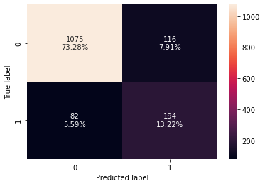

```python
#Fitting the model
d_tree = DecisionTreeClassifier(random_state=1)
d_tree.fit(X_train,y_train)

#Calculating different metrics
d_tree_model_train_perf=model_performance_classification_sklearn(d_tree,X_train,y_train)
print("Training performance:\n",d_tree_model_train_perf)
d_tree_model_test_perf=model_performance_classification_sklearn(d_tree,X_test,y_test)
print("Testing performance:\n",d_tree_model_test_perf)

#Creating confusion matrix
confusion_matrix_sklearn(d_tree,X_test,y_test)
```

- The decision tree is overfitting the training data as there is a significant difference between training and test scores for all the metrics except Accuracy.
- The test recall is moderately low around 70% only and accuracy is better with 86%.

## Hyperparameter Tuning

```python
#Choose the type of classifier.
dtree_estimator = DecisionTreeClassifier(class_weight={0:0.18,1:0.82},random_state=1)

# Grid of parameters to choose from
parameters = {'max_depth': np.arange(2,30),
              'min_samples_leaf': [1, 2, 5, 7, 10],
              'max_leaf_nodes' : [2, 3, 5, 10,15],
              'min_impurity_decrease': [0.0001,0.001,0.01,0.1]
             }

# Type of scoring used to compare parameter combinations
scorer = metrics.make_scorer(metrics.f1_score)

# Run the grid search
grid_obj = GridSearchCV(dtree_estimator, parameters, scoring=scorer,n_jobs=-1)
grid_obj = grid_obj.fit(X_train, y_train)

# Set the clf to the best combination of parameters
dtree_estimator = grid_obj.best_estimator_

# Fit the best algorithm to the data.
dtree_estimator.fit(X_train, y_train)
```

```
DecisionTreeClassifier(class_weight={0: 0.18, 1: 0.82}, max_depth=5,
                       max_leaf_nodes=15, min_impurity_decrease=0.0001,
                       random_state=1)
```

```
Training performance:
    Accuracy  Recall  Precision   F1
0       1.0     1.0        1.0  1.0
Testing performance:
    Accuracy    Recall  Precision        F1
0  0.865031  0.702899   0.625806  0.662116
```

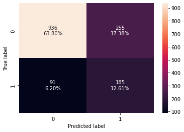

```python
#Calculating different metrics
dtree_estimator_model_train_perf=model_performance_classification_sklearn(d_tree,X_train,y_train)
print("Training performance:\n",dtree_estimator_model_train_perf)
dtree_estimator_model_test_perf=model_performance_classification_sklearn(d_tree,X_test,y_test)
print("Testing performance:\n",dtree_estimator_model_test_perf)

#Creating confusion matrix
confusion_matrix_sklearn(dtree_estimator,X_test,y_test)
```

## Random Forest Classifier

```
Training performance:
    Accuracy  Recall  Precision   F1
0       1.0     1.0        1.0  1.0
Testing performance:
    Accuracy   Recall  Precision        F1
0  0.916837  0.57971   0.963855  0.723982
```

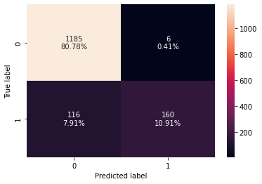

```python
#Fitting the model
rf_estimator = RandomForestClassifier(random_state=1)
rf_estimator.fit(X_train,y_train)

#Calculating different metrics
rf_estimator_model_train_perf=model_performance_classification_sklearn(rf_estimator,X_train,y_train)
print("Training performance:\n",rf_estimator_model_train_perf)
rf_estimator_model_test_perf=model_performance_classification_sklearn(rf_estimator,X_test,y_test)
print("Testing performance:\n",rf_estimator_model_test_perf)

#Creating confusion matrix
confusion_matrix_sklearn(rf_estimator,X_test,y_test)
```

- Random forest is also overfitting the training data as there is a difference between training and test scores for all the metrics.
- The test recall is even lower than the decision tree but other values Accuracy, precision and F1 are a higher

## Hyperparameter Tuning

```python
# Choose the type of classifier.
rf_tuned = RandomForestClassifier(random_state=1)

# Grid of parameters to choose from
## add from article
parameters = {
    "class_weight": [{0: 0.18, 1: 0.82}],
    "n_estimators": [100,150,200,250],
    "min_samples_leaf": np.arange(5, 10),
    "max_features": np.arange(0.2, 0.7, 0.1),
    "max_samples": np.arange(0.3, 0.7, 0.1),
}

# Type of scoring used to compare parameter combinations
acc_scorer = metrics.make_scorer(metrics.recall_score)

# Run the grid search
grid_obj = GridSearchCV(rf_tuned, parameters, scoring=acc_scorer,cv=5,n_jobs=-1)
grid_obj = grid_obj.fit(X_train, y_train)

# Set the clf to the best combination of parameters
rf_tuned = grid_obj.best_estimator_

# Fit the best algorithm to the data.
rf_tuned.fit(X_train, y_train)
```

```
RandomForestClassifier(class_weight={0: 0.18, 1: 0.82},
                       max_features=0.6000000000000001,
                       max_samples=0.6000000000000001, min_samples_leaf=8,
                       n_estimators=250, random_state=1)
```

```
Training performance:
    Accuracy    Recall  Precision        F1
0  0.899445  0.858696   0.686104  0.762759
Testing performance:
    Accuracy    Recall  Precision        F1
0  0.861622  0.663043   0.624573  0.643234
```

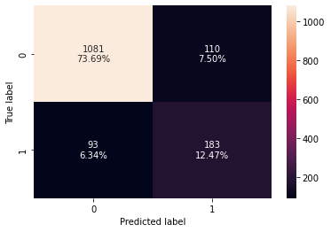

```python
#Calculating different metrics
rf_tuned_model_train_perf=model_performance_classification_sklearn(rf_tuned,X_train,y_train)
print("Training performance:\n",rf_tuned_model_train_perf)
rf_tuned_model_test_perf=model_performance_classification_sklearn(rf_tuned,X_test,y_test)
print("Testing performance:\n",rf_tuned_model_test_perf)

#Creating confusion matrix
confusion_matrix_sklearn(rf_tuned,X_test,y_test)
```

- The test recall has moderately increased after hyperparameter tuning. The recall now is almost same as Decision model.
- The confusion matrix shows that the model can identify who do not purchase the product.

## Bagging Classifier

```
   Accuracy    Recall  Precision        F1
0  0.993569  0.965839        1.0  0.982622
   Accuracy    Recall  Precision        F1
0   0.90184  0.561594   0.870787  0.682819
```

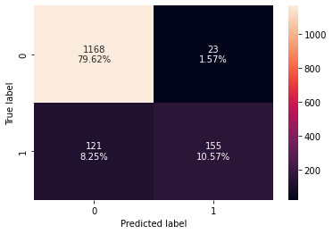

```python
#Fitting the model
bagging_classifier = BaggingClassifier(random_state=1)
bagging_classifier.fit(X_train,y_train)

#Calculating different metrics
bagging_classifier_model_train_perf=model_performance_classification_sklearn(bagging_classifier,X_train,y_train)
print(bagging_classifier_model_train_perf)
bagging_classifier_model_test_perf=model_performance_classification_sklearn(bagging_classifier,X_test,y_test)
print(bagging_classifier_model_test_perf)

#Creating confusion matrix
confusion_matrix_sklearn(bagging_classifier,X_test,y_test)
```

- Huse difference in recall between test and train data.
- It is also overfitting the training data.

## Hyperparameter Tuning

```python
# Choose the type of classifier.
bagging_estimator_tuned = BaggingClassifier(random_state=1)

# Grid of parameters to choose from
parameters = {'max_samples': [0.7,0.8,0.9,1],
              'max_features': [0.7,0.8,0.9,1],
              'n_estimators' : [10,20,30,40,50],
             }

# Type of scoring used to compare parameter combinations
scorer = metrics.make_scorer(metrics.f1_score)

# Run the grid search
grid_obj = GridSearchCV(bagging_estimator_tuned, parameters, scoring=scorer,cv=5, n_jobs=-1)
grid_obj = grid_obj.fit(X_train, y_train)

# Set the clf to the best combination of parameters
bagging_estimator_tuned = grid_obj.best_estimator_

# Fit the best algorithm to the data.
bagging_estimator_tuned.fit(X_train, y_train)
```

```
BaggingClassifier(max_features=0.9, max_samples=0.9, n_estimators=50,
                  random_state=1)
```

```
   Accuracy    Recall  Precision        F1
0  0.999708  0.998447        1.0  0.999223
   Accuracy    Recall  Precision        F1
0   0.92229  0.648551   0.913265  0.758475
```

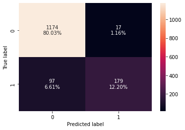

```python
#Calculating different metrics
bagging_estimator_tuned_model_train_perf=model_performance_classification_sklearn(bagging_estimator_tuned,X_train,y_train)
print(bagging_estimator_tuned_model_train_perf)
bagging_estimator_tuned_model_test_perf=model_performance_classification_sklearn(bagging_estimator_tuned,X_test,y_test)
print(bagging_estimator_tuned_model_test_perf)

#Creating confusion matrix
confusion_matrix_sklearn(bagging_estimator_tuned,X_test,y_test)
```

- The test recall has increased after hyperparameter tuning and the model is still overfitting the training data.
- The confusion matrix shows that the model is not good at identifying customers who really do not buy the product.

## AdaBoost Classifier

```
   Accuracy   Recall  Precision       F1
0  0.844782  0.28882   0.718147  0.41196
   Accuracy    Recall  Precision       F1
0  0.848671  0.297101   0.745455  0.42487
```

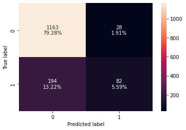

```python
#Fitting the model
ab_classifier = AdaBoostClassifier(random_state=1)
ab_classifier.fit(X_train,y_train)

#Calculating different metrics
ab_classifier_model_train_perf=model_performance_classification_sklearn(ab_classifier,X_train,y_train)
print(ab_classifier_model_train_perf)
ab_classifier_model_test_perf=model_performance_classification_sklearn(ab_classifier,X_test,y_test)
print(ab_classifier_model_test_perf)

#Creating confusion matrix
confusion_matrix_sklearn(ab_classifier,X_test,y_test)
```

- AdaBoost is generalizing well but it is giving very poor performance, in terms of recall and F1 Score as compared to the decision tree and random forest model.

## Hyperparameter Tuning

```python
# Choose the type of classifier.
abc_tuned = AdaBoostClassifier(random_state=1)

# Grid of parameters to choose from
parameters = {
    #Let's try different max_depth for base_estimator
    "base_estimator":[DecisionTreeClassifier(max_depth=1),DecisionTreeClassifier(max_depth=2),
                      DecisionTreeClassifier(max_depth=3)],
    "n_estimators": np.arange(10,110,10),
    "learning_rate":np.arange(0.1,2,0.1)
}

# Type of scoring used to compare parameter  combinations
scorer = metrics.make_scorer(metrics.f1_score)

# Run the grid search
grid_obj = GridSearchCV(abc_tuned, parameters, scoring=scorer,cv=5, n_jobs=-1)
grid_obj = grid_obj.fit(X_train, y_train)

# Set the clf to the best combination of parameters
abc_tuned = grid_obj.best_estimator_

# Fit the best algorithm to the data.
abc_tuned.fit(X_train, y_train)
```

```
AdaBoostClassifier(base_estimator=DecisionTreeClassifier(max_depth=3),
                   learning_rate=1.3000000000000003, n_estimators=100,
                   random_state=1)
```

```
   Accuracy    Recall  Precision        F1
0  0.989184  0.958075   0.984051  0.970889
   Accuracy    Recall  Precision        F1
0  0.886162  0.630435   0.728033  0.675728
```

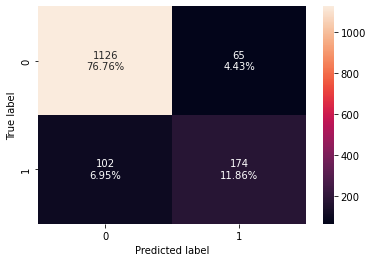

```python
#Calculating different metrics
abc_tuned_model_train_perf=model_performance_classification_sklearn(abc_tuned,X_train,y_train)
print(abc_tuned_model_train_perf)
abc_tuned_model_test_perf=model_performance_classification_sklearn(abc_tuned,X_test,y_test)
print(abc_tuned_model_test_perf)

#Creating confusion matrix
confusion_matrix_sklearn(abc_tuned,X_test,y_test)
```

- After tuning AdaBoost recall has improved and almost same as random and bagging (after tuning) but it is overfitting the test data.

## Gradient Boosting Classifier

```
Training performance:
    Accuracy    Recall  Precision        F1
0  0.882783  0.437888   0.878505  0.584456
Testing performance:
    Accuracy    Recall  Precision        F1
0  0.868439  0.387681   0.816794  0.525799
```

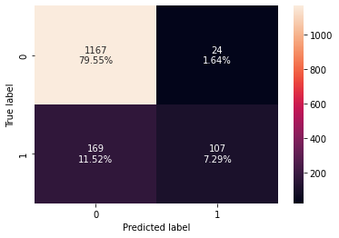

```python
#Fitting the model
gb_classifier = GradientBoostingClassifier(random_state=1)
gb_classifier.fit(X_train,y_train)

#Calculating different metrics
gb_classifier_model_train_perf=model_performance_classification_sklearn(gb_classifier,X_train,y_train)
print("Training performance:\n",gb_classifier_model_train_perf)
gb_classifier_model_test_perf=model_performance_classification_sklearn(gb_classifier,X_test,y_test)
print("Testing performance:\n",gb_classifier_model_test_perf)

#Creating confusion matrix
confusion_matrix_sklearn(gb_classifier,X_test,y_test)
```

- The test recall is way lower than other models except Adaboost.
- The confusion matrix shows that the model is not good at identifying customers who really do not buy the product.

## Hyperparameter Tuning

```python
# Choose the type of classifier.
gbc_tuned = GradientBoostingClassifier(init=AdaBoostClassifier(random_state=1),random_state=1)

# Grid of parameters to choose from
parameters = {
    "n_estimators": [100,150,200,250],
    "subsample":[0.8,0.9,1],
    "max_features":[0.7,0.8,0.9,1]
}

# Type of scoring used to compare parameter combinations
scorer = metrics.make_scorer(metrics.f1_score)

# Run the grid search
grid_obj = GridSearchCV(gbc_tuned, parameters, scoring=scorer,cv=5, n_jobs=-1)
grid_obj = grid_obj.fit(X_train, y_train)

# Set the clf to the best combination of parameters
gbc_tuned = grid_obj.best_estimator_

# Fit the best algorithm to the data.
gbc_tuned.fit(X_train, y_train)
```

```
GradientBoostingClassifier(init=AdaBoostClassifier(random_state=1),
                           max_features=0.9, n_estimators=250, random_state=1,
                           subsample=0.8)
```

```
Training performance:
    Accuracy    Recall  Precision        F1
0   0.91786  0.607143   0.933174  0.735654
Testing performance:
    Accuracy    Recall  Precision        F1
0  0.873892  0.456522   0.782609  0.576659
```

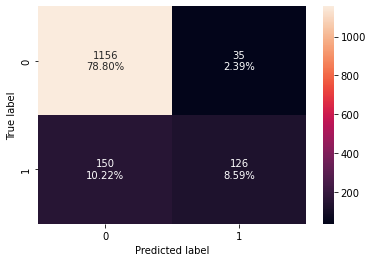

```python
#Calculating different metrics
gbc_tuned_model_train_perf=model_performance_classification_sklearn(gbc_tuned,X_train,y_train)
print("Training performance:\n",gbc_tuned_model_train_perf)
gbc_tuned_model_test_perf=model_performance_classification_sklearn(gbc_tuned,X_test,y_test)
print("Testing performance:\n",gbc_tuned_model_test_perf)

#Creating confusion matrix
confusion_matrix_sklearn(gbc_tuned,X_test,y_test)
```

- The test recall is slightly improved after tuning but it is way lower than decision and random models
- The confusion matrix shows that the model is not good at identifying customers who really do not buy the product.

## XGBoost Classifier

```
Training performance:
    Accuracy    Recall  Precision        F1
0  0.998831  0.993789        1.0  0.996885
Testing performance:
    Accuracy    Recall  Precision        F1
0    0.9182  0.663043   0.871429  0.753086
```

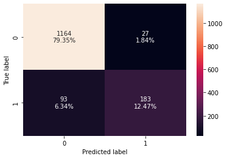

```python
#Fitting the model
xgb_classifier = XGBClassifier(random_state=1, eval_metric='logloss')
xgb_classifier.fit(X_train,y_train)

#Calculating different metrics
xgb_classifier_model_train_perf=model_performance_classification_sklearn(xgb_classifier,X_train,y_train)
print("Training performance:\n",xgb_classifier_model_train_perf)
xgb_classifier_model_test_perf=model_performance_classification_sklearn(xgb_classifier,X_test,y_test)
print("Testing performance:\n",xgb_classifier_model_test_perf)

#Creating confusion matrix
confusion_matrix_sklearn(xgb_classifier,X_test,y_test)
```

- The test recall is kind of similar with decision and random models. But the data is overfitting with test data.
- The confusion matrix shows that the model can indetify customers who really do not buy the product.

## Hyperparameter Tuning

```python
# Choose the type of classifier.
xgb_tuned = XGBClassifier(random_state=1, eval_metric='logloss')


# Grid of parameters to choose from
parameters = {
        "n_estimators": [10,30,50],
    "scale_pos_weight":[1,2,5],
    "subsample":[0.7,0.9,1],
    "learning_rate":[0.05, 0.1,0.2],
    "colsample_bytree":[0.7,0.9,1],
    "colsample_bylevel":[0.5,0.7,1]
}

# Type of scoring used to compare parameter combinations
scorer = metrics.make_scorer(metrics.r2_score)

# Run the grid search
grid_obj = GridSearchCV(xgb_tuned, parameters, scoring=scorer,cv=5)
grid_obj = grid_obj.fit(X_train, y_train)

# Set the clf to the best combination of parameters
xgb_tuned = grid_obj.best_estimator_

# Fit the best algorithm to the data.
xgb_tuned.fit(X_train, y_train)
```

```
XGBClassifier(base_score=0.5, booster='gbtree', colsample_bylevel=1,
              colsample_bynode=1, colsample_bytree=0.7,
              enable_categorical=False, eval_metric='logloss', gamma=0,
              gpu_id=-1, importance_type=None, interaction_constraints='',
              learning_rate=0.2, max_delta_step=0, max_depth=6,
              min_child_weight=1, missing=nan, monotone_constraints='()',
              n_estimators=50, n_jobs=8, num_parallel_tree=1, predictor='auto',
              random_state=1, reg_alpha=0, reg_lambda=1, scale_pos_weight=2,
              subsample=1, tree_method='exact', validate_parameters=1,
              verbosity=None)
```

```
Training performance:
    Accuracy    Recall  Precision        F1
0  0.976323  0.916149    0.95624  0.935765
Testing performance:
    Accuracy    Recall  Precision        F1
0  0.920927  0.710145   0.844828  0.771654
```

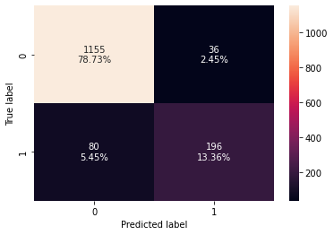

```python
#Calculating different metrics
xgb_tuned_model_train_perf=model_performance_classification_sklearn(xgb_tuned,X_train,y_train)
print("Training performance:\n",xgb_tuned_model_train_perf)
xgb_tuned_model_test_perf=model_performance_classification_sklearn(xgb_tuned,X_test,y_test)
print("Testing performance:\n",xgb_tuned_model_test_perf)

#Creating confusion matrix
confusion_matrix_sklearn(xgb_tuned,X_test,y_test)
```

- The overfitting has reduced slightly when compared with other models. Compared to other models this gives slightly better performance.

## Stacking Classifier

```python
estimators = [('Random Forest',rf_tuned), ('Gradient Boosting',gbc_tuned), ('Decision Tree',dtree_estimator)]

final_estimator = xgb_tuned

stacking_classifier= StackingClassifier(estimators=estimators,final_estimator=final_estimator)

stacking_classifier.fit(X_train,y_train)
```

```
StackingClassifier(estimators=[('Random Forest',
                                RandomForestClassifier(class_weight={0: 0.18,
                                                                     1: 0.82},
                                                       max_features=0.6000000000000001,
                                                       max_samples=0.6000000000000001,
                                                       min_samples_leaf=8,
                                                       n_estimators=250,
                                                       random_state=1)),
                               ('Gradient Boosting',
                                GradientBoostingClassifier(init=AdaBoostClassifier(random_state=1),
                                                           max_features=0.9,
                                                           n_estimators=250,
                                                           random_state=1...
                                                 gpu_id=-1,
                                                 importance_type=None,
                                                 interaction_constraints='',
                                                 learning_rate=0.2,
                                                 max_delta_step=0, max_depth=6,
                                                 min_child_weight=1,
                                                 missing=nan,
                                                 monotone_constraints='()',
                                                 n_estimators=50, n_jobs=8,
                                                 num_parallel_tree=1,
                                                 predictor='auto',
                                                 random_state=1, reg_alpha=0,
                                                 reg_lambda=1,
                                                 scale_pos_weight=2,
                                                 subsample=1,
                                                 tree_method='exact',
                                                 validate_parameters=1,
                                                 verbosity=None))
```

```
Training performance:
    Accuracy    Recall  Precision        F1
0  0.920783  0.809006   0.778774  0.793602
Testing performance:
    Accuracy    Recall  Precision        F1
0  0.861622  0.597826   0.642023  0.619137
```

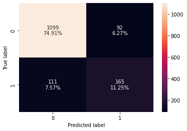

```python
#Calculating different metrics
stacking_classifier_model_train_perf=model_performance_classification_sklearn(stacking_classifier,X_train,y_train)
print("Training performance:\n",stacking_classifier_model_train_perf)
stacking_classifier_model_test_perf=model_performance_classification_sklearn(stacking_classifier,X_test,y_test)
print("Testing performance:\n",stacking_classifier_model_test_perf)

#Creating confusion matrix
confusion_matrix_sklearn(stacking_classifier,X_test,y_test)
```

## Comparing all models

```python
# training performance comparison

models_train_comp_df = pd.concat(
    [d_tree_model_train_perf.T,dtree_estimator_model_train_perf.T,rf_estimator_model_train_perf.T,rf_tuned_model_train_perf.T,
     bagging_classifier_model_train_perf.T,bagging_estimator_tuned_model_train_perf.T,ab_classifier_model_train_perf.T,
     abc_tuned_model_train_perf.T,gb_classifier_model_train_perf.T,gbc_tuned_model_train_perf.T,xgb_classifier_model_train_perf.T,
    xgb_tuned_model_train_perf.T,stacking_classifier_model_train_perf.T],
    axis=1,
)
models_train_comp_df.columns = [
    "Decision Tree",
    "Decision Tree Estimator",
    "Random Forest Estimator",
    "Random Forest Tuned",
    "Bagging Classifier",
    "Bagging Estimator Tuned",
    "Adaboost Classifier",
    "Adabosst Classifier Tuned",
    "Gradient Boost Classifier",
    "Gradient Boost Classifier Tuned",
    "XGBoost Classifier",
    "XGBoost Classifier Tuned",
    "Stacking Classifier"]
print("Training performance comparison:")
models_train_comp_df
```

```
Training performance comparison:
```

|  | Decision Tree | Decision Tree Estimator | Random Forest Estimator | Random Forest Tuned | Bagging Classifier | Bagging Estimator Tuned | Adaboost Classifier | Adabosst Classifier Tuned | Gradient Boost Classifier | Gradient Boost Classifier Tuned | XGBoost Classifier | XGBoost Classifier Tuned | Stacking Classifier |
| --- | --- | --- | --- | --- | --- | --- | --- | --- | --- | --- | --- | --- | --- |
| Accuracy | 1.0 | 1.0 | 1.0 | 0.899445 | 0.993569 | 0.999708 | 0.844782 | 0.989184 | 0.882783 | 0.917860 | 0.998831 | 0.976323 | 0.920783 |
| Recall | 1.0 | 1.0 | 1.0 | 0.858696 | 0.965839 | 0.998447 | 0.288820 | 0.958075 | 0.437888 | 0.607143 | 0.993789 | 0.916149 | 0.809006 |
| Precision | 1.0 | 1.0 | 1.0 | 0.686104 | 1.000000 | 1.000000 | 0.718147 | 0.984051 | 0.878505 | 0.933174 | 1.000000 | 0.956240 | 0.778774 |
| F1 | 1.0 | 1.0 | 1.0 | 0.762759 | 0.982622 | 0.999223 | 0.411960 | 0.970889 | 0.584456 | 0.735654 | 0.996885 | 0.935765 | 0.793602 |

```python
# testing performance comparison

models_test_comp_df = pd.concat(
    [d_tree_model_test_perf.T,dtree_estimator_model_test_perf.T,rf_estimator_model_test_perf.T,rf_tuned_model_test_perf.T,
     bagging_classifier_model_test_perf.T,bagging_estimator_tuned_model_test_perf.T,ab_classifier_model_test_perf.T,
     abc_tuned_model_test_perf.T,gb_classifier_model_test_perf.T,gbc_tuned_model_test_perf.T,xgb_classifier_model_test_perf.T,
    xgb_tuned_model_test_perf.T,stacking_classifier_model_test_perf.T],
    axis=1,
)
models_test_comp_df.columns = [
    "Decision Tree",
    "Decision Tree Estimator",
    "Random Forest Estimator",
    "Random Forest Tuned",
    "Bagging Classifier",
    "Bagging Estimator Tuned",
    "Adaboost Classifier",
    "Adabosst Classifier Tuned",
    "Gradient Boost Classifier",
    "Gradient Boost Classifier Tuned",
    "XGBoost Classifier",
    "XGBoost Classifier Tuned",
    "Stacking Classifier"]
print("Testing performance comparison:")
models_test_comp_df
```

```
Testing performance comparison:
```

|  | Decision Tree | Decision Tree Estimator | Random Forest Estimator | Random Forest Tuned | Bagging Classifier | Bagging Estimator Tuned | Adaboost Classifier | Adabosst Classifier Tuned | Gradient Boost Classifier | Gradient Boost Classifier Tuned | XGBoost Classifier | XGBoost Classifier Tuned | Stacking Classifier |
| --- | --- | --- | --- | --- | --- | --- | --- | --- | --- | --- | --- | --- | --- |
| Accuracy | 0.865031 | 0.865031 | 0.916837 | 0.861622 | 0.901840 | 0.922290 | 0.848671 | 0.886162 | 0.868439 | 0.873892 | 0.918200 | 0.920927 | 0.861622 |
| Recall | 0.702899 | 0.702899 | 0.579710 | 0.663043 | 0.561594 | 0.648551 | 0.297101 | 0.630435 | 0.387681 | 0.456522 | 0.663043 | 0.710145 | 0.597826 |
| Precision | 0.625806 | 0.625806 | 0.963855 | 0.624573 | 0.870787 | 0.913265 | 0.745455 | 0.728033 | 0.816794 | 0.782609 | 0.871429 | 0.844828 | 0.642023 |
| F1 | 0.662116 | 0.662116 | 0.723982 | 0.643234 | 0.682819 | 0.758475 | 0.424870 | 0.675728 | 0.525799 | 0.576659 | 0.753086 | 0.771654 | 0.619137 |

- A tuned XGBoost is the best model for our data as it has the highest test recall and giving a generalized performance as compared to other models where as decision tree is next. But decision tree (including tuned) also has next highest recall but it more overfitting than tuned XGBoost model.

## Feature importance of Tuned XGBoost Classifer

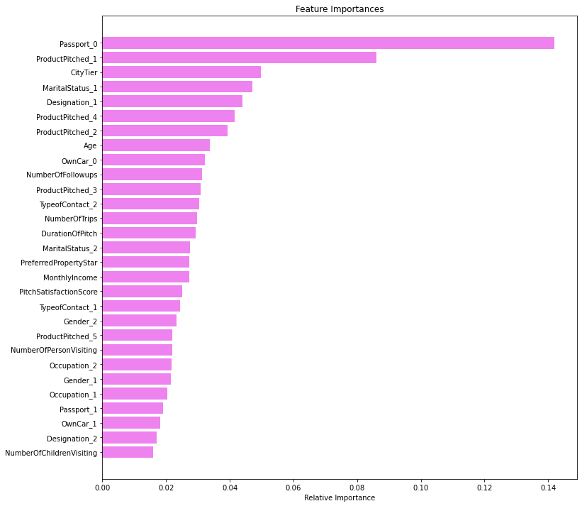

```python
feature_names = X_train.columns
importances = xgb_tuned.feature_importances_
indices = np.argsort(importances)

plt.figure(figsize=(12,12))
plt.title('Feature Importances')
plt.barh(range(len(indices)), importances[indices], color='violet', align='center')
plt.yticks(range(len(indices)), [feature_names[i] for i in indices])
plt.xlabel('Relative Importance')
plt.show()
```

- The most important feature is passpost.
- The next ones are product pitched, citytier and marital status.

# Conclusion and Recommendations